# W9：估計理論——捕捉真理的網

心理教育統計 2026

授課教師：陳紹慶 | e-mail: csc2009@mail.tcu.edu.tw

2026/04/27

# 本週學習目標

**理解概念**：

1. 區分「點估計」與「區間估計」
2. 正確解讀 **95% 信賴區間 (CI)** 的意義
3. 理解**自由度 (df)** 與 **t 分佈**的由來

**數學工具**：

1. 信賴區間公式：$CI = \bar{X} \pm t_{(df, \alpha/2)} \times SE$
2. 自由度：$df = N - 1$

**軟體操作**：

1. jamovi Descriptives 模組的 CI for Mean
2. jamovi T-tests 模組的One-sample T test

## 對應教材

- 《用 jamovi 上手統計學》
  - [第 8 章：運用樣本估計未知量數](https://scgeeker.github.io/lsj-book-zh_tw/08-Estimating-unknown-quantities-from-a-sample.html#sec-Estimating-point-of-parameters)（8.4-8.6）

**簡報示範**：互動式網頁

**作業資料**：個人化 `W09_CI_Samples_[學號].csv`

# Part 1：點估計——通常是錯的🧠

## 回顧 W8：已經知道的事

W8 你學到了：

- 每次從母群取樣，得到的 $\bar{X}$ 都不太一樣
- $\bar{X}$ 的取樣分佈逼近以 $\mu$ 為中心的常態分佈，$\sigma$ = $SE$
- $N$ 越大 → $SE$ 越小 → $\bar{X}$ 越接近 $\mu$
- **問題**：既然 $\bar{X}$ 每次都不一樣，我們怎麼知道真正的 $\mu$ 是多少？

## 點估計：最佳猜測

**點估計（Point Estimate）**：用單一數值猜測母群參數

- $\hat{\mu} = \bar{X}$（樣本平均數是母群平均數的最佳估計值）
- $\widehat{\sigma/\sqrt{N}} = \frac{s}{\sqrt{n}}$（樣本**標準誤**是取樣分佈標準差的最佳估計值）🎯

## 點估計的問題

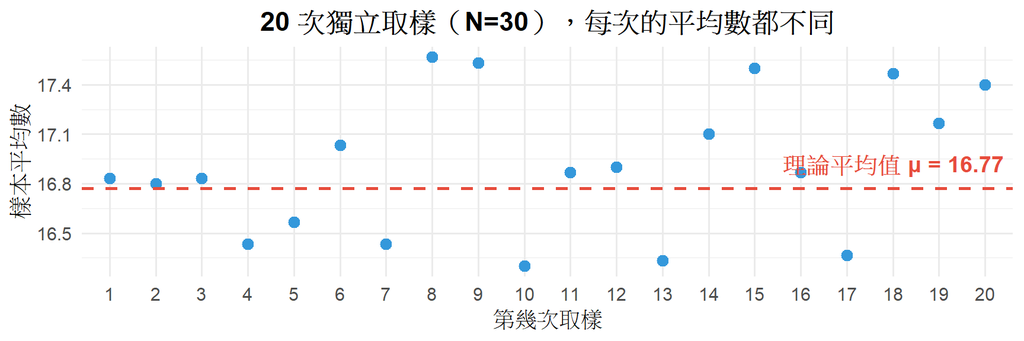

> 每個樣本平均數都是一次「最佳猜測」，但幾乎沒有一次剛好命中理論平均值！

## 統計報告的難題

- 我只能做一次取樣，計算一個樣本平均數，如何保證這一次是最接近理論平均值的估計值？

## 魚槍 vs. 漁網

**點估計 = 魚槍**

- 瞄準一個點射出去
- 命中目標的機率**極低**
- $\bar{X} = 17.3$ → 真的是 17.3 嗎？

**區間估計 = 漁網**

- 張開一定範圍的網
- **捕獲目標的機率很高**
- $\bar{X} \in [16.5, 18.1]$ → 更有用！

> 統計學的智慧：承認不確定性，用**範圍**取代**精確值**

# Part 2：信賴區間——撒網的藝術🧠

## 信賴區間（CI）的直覺

**95% 信賴區間**的意思是：

如果我用同樣的方法**反覆取樣 100 次**，每次都計算一個區間…

→ 大約有 **95 個區間**會包含真正的 $\mu$

→ 大約有 **5 個區間**會落空

## 信賴區間的模擬

[interactive chart not shown]

- 所有樣本平均值會堆疊為[取樣分佈](https://scgeeker.github.io/lsj_2026_lecture_slides/W08_slides.html#/clt-%E9%AD%94%E6%B3%95%E5%81%8F%E6%85%8B%E8%AE%8A%E5%B8%B8%E6%85%8B)

## 什麼是 $\sigma$ 未知

- 多數統計實務**無法直接觀測母群**，$\sigma$（母群標準差）是未知參數
- **中央極限定理**保證：取樣分佈近似常態，$SE = \frac{\sigma}{\sqrt{N}}$——但 $\sigma$ 本身未知
- [t分佈](https://zh.wikipedia.org/zh-tw/%E5%8F%B8%E5%BE%92%E9%A0%93t%E5%88%86%E5%B8%83)僅有單一參數$\nu$，即**自由度**，稍後可知**自由度**與$N$的密切關係。

## CI 的公式($\sigma$未知)

$$CI = \bar{X} \pm t_{(df,\; \alpha/2)}
\times SE$$

拆開來看：

- $\bar{X}$：樣本平均數（網子的**中心**）
- $SE = \frac{s}{\sqrt{N}}$：標準誤（網子的**基本寬度**）
- $t_{(df,\; \alpha/2)}$：t 臨界值（網子能夠**撐開**的倍數）
- $df = N - 1$：自由度（決定倍數大小）

## CI 的寬度由什麼決定？

$$\text{CI 寬度} = 2 \times t_{(df,\;
\alpha/2)} \times SE = 2 \times t_{(df,\; \alpha/2)} \times
\frac{s}{\sqrt{N}}$$

**兩個關鍵因素**：

1. **$N$ 越大** → $SE$ 越小 + $t$ 越接近常態 → 網子越窄
2. **信心水準越高**（95% vs 99%） → $t$ 越大 → 網子越寬

## CI 的範圍之內一定有$\mu$？

- 不一定，CI反映報告者有多少信心，認為此次結果的估計範圍包含$\mu$的**可能性**
- **中央極限定理**只有保證，隨機樣本的N是估計精確度的根本。CI的*臨界值*是提示讀者，報告者的信心邊界。
- 精確度與信心的取捨：想要更有信心？就得接受更寬的網子。

# Part 3：自由度——估計的代價🧠

## 為什麼要計算 $s$

- 許多研究實際上無法得知 $\sigma$
- 計算 CI 需要估計標準誤（SE）
- **代價**：$s$ 本身也有誤差 → 增加 CI 不確定性 → 擴張信心邊界

|  | $\sigma$ 已知 | $\sigma$ 未知 |
| --- | --- | --- |
| 臨界值來源 | 常態分佈 Z | **t 分佈**（$df = N-1$） |
| 公式 | $\bar{X} \pm 1.96 \times SE$ | $\bar{X} \pm t_{(df,\;\alpha/2)} \times SE$ |
| 實務上 | 幾乎不可能 | **真實狀況** |

## 為什麼不是除以 $N$？

回想 W08 的 $SE$ 公式：

$$SE = \frac{s}{\sqrt{N}} \quad
\text{其中} \quad s = \sqrt{\frac{\sum(X_i - \bar{X})^2}{N -
1}}$$

**問題**：$s$ 的分母為什麼是 $N - 1$ 而不是 $N$？

- 除以 $N-1$ 使 $s^2$ 成為 $\sigma^2$ 的**不偏估計值**（Bessel’s correction），否則會造成低估

### 聚餐 AA 制的譬喻

5 個人聚餐，限定預算 $1000 元（已知）

- 第 1 個人出 $250 → 自由選擇 ✓
- 第 2 個人出 $150 → 自由選擇 ✓
- 第 3 個人出 $200 → 自由選擇 ✓
- 第 4 個人出 $300 → 自由選擇 ✓
- 第 5 個人出 $100 → **沒得選！** ✗（被前 4 人決定了）

**自由度 = 5 - 1 = 4**

> 當你用 $\bar{X}$ 來計算 $s$ 時，$\bar{X}$ 就像「已知的總帳單」：最後資料的離均差，已被先到資料決定。

## t 分佈：小樣本的「懲罰」

**功能**：*自由度*是決定t分佈形狀的唯一**參數**

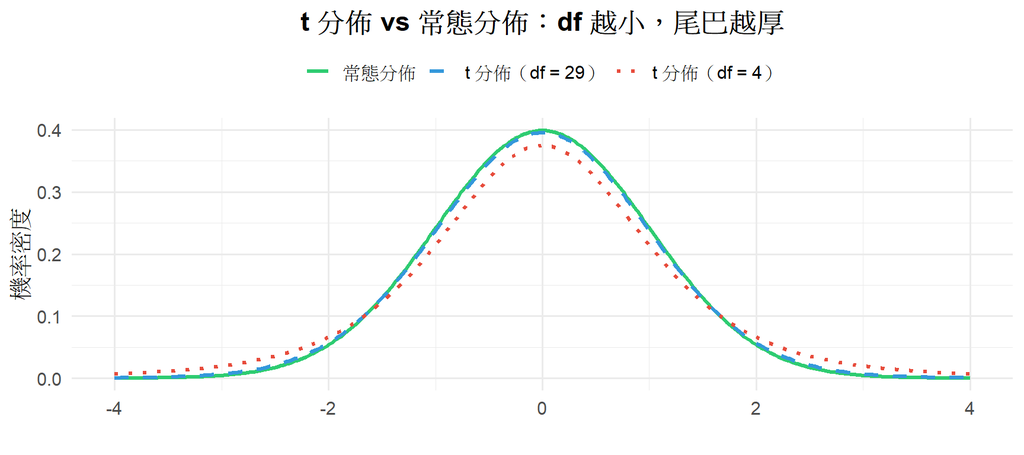

## t 分佈的關鍵特性

- df 越小 → 尾巴越厚 → $t$ 臨界值越大 → CI 越寬
- df 越大 → 越接近常態分佈 → $t$ 越接近 1.96

| $N$ | $df = N-1$ | $t_{0.025}$ | 相對於 1.96 |
| --- | --- | --- | --- |
| 5 | 4 | 2.776 | +42% |
| 10 | 9 | 2.262 | +15% |
| 30 | 29 | 2.045 | +4% |
| 100 | 99 | 1.984 | +1% |
| ∞ | ∞ | 1.960 | 0% |

> $N = 5$ 時，倍數比常態多了約 **40%** → CI 寬了 40%！

## N 對 CI 寬度的影響（模擬）

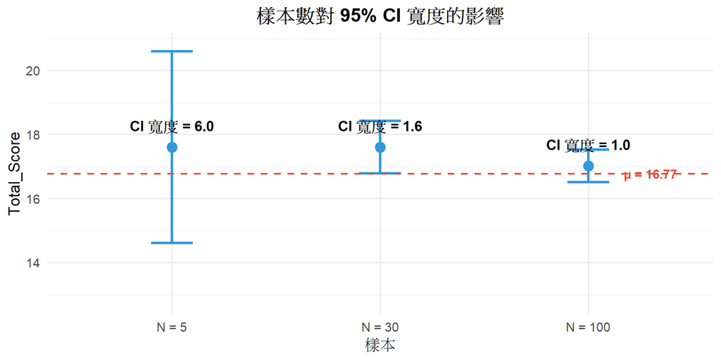

> **互動探索**：回到信賴區間模擬，調整樣本數 **N**，觀察 CI 寬度如何收窄；再切換 **Z / T** 兩種模式，看看小樣本時兩者差距有多明顯。

# Part 4：正確解讀 CI

## 最常見的錯誤

> ❌「母群平均數有 95% 的機率落在這個區間內」

**為什麼錯？**

- $\mu$ 是一個**固定的數字**（只是我們不知道） >- $\mu$ 不會「跑來跑去」，所以不能說它「有幾 % 的機率在某處」 >- 「機率」描述的是**方法**，不是**結果**

## 正確的解讀

> ✓「我們有 95% 的信心，這個區間涵蓋了母群平均數」

**更精確地說**：

如果我們用**相同的方法**反覆取樣、反覆計算 CI

- **長期而言**，95% 的區間會包含 $\mu$
- 眼前的**區間估計範圍**，要嘛包含、要嘛不包含；但我們**相信這個方法**會有效

## 釣魚的譬喻

- 95% CI ≠ 「魚有 95% 的機率被網子撈起來」
- 95% CI = 「這種撒網捕魚技術，**長期命中率**是 95%」

你無法確定**這一次**有沒有撈到

但是你信任**這個技術**——因為它的長期表現很好

## 用 jamovi 計算 CI

**操作步驟**：

> **Exploration → Descriptives**

1. 將變項拖入分析 2. 勾選 **Statistics → Confidence interval for Mean**

> **T-Tests → One-Sample T-test**

1. 將變項拖入分析 2. 設定 **Test value**（$\mu_0 = 15$） 3. 勾選 **Plots → Descriptive plots**

## 用 jamovi 計算 CI（續）

**解讀輸出**：

- **Mean**：點估計值 $\bar{X}$
- **95% CI Lower Bound**：區間下界
- **95% CI Upper Bound**：區間上界
- **S.E. Mean**：$SE = s / \sqrt{N}$
- **Statistic**：觀察 t 值（$t_{obs} = \frac{\bar{X} - \mu_0}{SE}$）

> **驗算**：$SE = \frac{\bar{X} - \mu_0}{t_{obs}}$ 應與 Descriptives 的 $SE$ 相符；CI 半寬 $= t_{critical} \times SE$

# Part 5：作業說明

## 本週作業：三種樣本的 CI 比較

**資料**：個人化 `W09_CI_Samples_[學號].csv`

你的資料包含 3 個變項：

| 變項 | 說明 |
| --- | --- |
| `Sample_N5` | Total_Score 樣本（N=5） |
| `Sample_N30` | Total_Score 樣本（N=30） |
| `Sample_N100` | Total_Score 樣本（N=100） |

三組都來自你的個人母群（與 W4-W8 相同）

## 任務 1a：計算三組的 95% CI

**操作**：

1. 匯入 CSV，設定三個變項為 **Continuous**
2. 使用 **Exploration → Descriptives**
3. 勾選 **Statistics**：Mean, SD, S.E. Mean, **CI for Mean (95%)**

**記錄**：整理三組的描述統計與 CI

|  | N=5 | N=30 | N=100 |
| --- | --- | --- | --- |
| Mean |  |  |  |
| SD |  |  |  |
| SE |  |  |  |
| 95% CI 下界 |  |  |  |
| 95% CI 上界 |  |  |  |
| CI 寬度 |  |  |  |

## 任務 1b：t 檢定視覺化 + SE 驗算

**操作**（以 `Sample_N30` 為例）：

1. **T-Tests → One-Sample T-test**  
2. 將 `Sample_N30` 拖入分析；設定 **Test value = 15**  
3. 勾選 **Plots → Descriptive plots**

**記錄並驗算**：

- 計算各變項 $SE = (\bar{X} - 15) \div t_{obs}$  
- 計算結果是否與描述統計模組計算的 SE 一致？

> 本週 One-Sample T-test 的目的是取得**視覺化圖形**與**驗算工具**；*p* 值意義下週討論。

## 任務 2：CI 寬度的視覺化比較

**操作**：在報告中說明

- 三組 CI 的寬度分別是多少？
- 為什麼 N=5 的 CI 最寬？請從 **SE** 和 **t 臨界值**兩個角度解釋

**提示**：

- $SE = SD / \sqrt{N}$，N 越大 → SE 越小
- $t_{(df=4)} = 2.776$ vs $t_{(df=29)} = 2.045$ vs $t_{(df=99)} = 1.984$

## 任務 3：觀念辨析

在報告中回答以下問題：

1. **CI 解讀**：如果你的某項分析之 95% CI 有包含`15`，你想寫「母群平均數有 95% 的機率是`15`」。這樣的結論正確嗎？請說明理由並修正。
2. **自由度**：為什麼計算樣本標準差時要除以 $N-1$ 而不是 $N$？請用自己的話解釋。
3. **N 的代價**：如果你是研究者，想將 CI 寬度縮小一半，你需要將樣本數增加多少倍？（提示：想想 $SE = SD / \sqrt{N}$ 的數學關係）

## 繳交要求

**檔案 1：學號_姓名_W09_Lab.omv**

- 3 個變項的 Descriptives 分析（Mean, SD, S.E. Mean, CI for Mean） - 3 個變項的的 One-Sample T-test 分析（Test value = 15，含 Descriptive plot）

**檔案 2：學號_姓名_W09_Report.docx**

- 描述統計整理表（三組 CI 比較） - CI 寬度分析 - 反思問題：回答 3 題觀念問題

**繳交期限**：今日4/27 12:00pm前

# 小結與展望

## 本週核心概念

1. **點估計 vs 區間估計**：用範圍取代精確值，承認不確定性
2. **95% CI**：長期而言 95% 的區間包含 $\mu$（方法的可靠度）
3. **自由度**：估計 $\sigma$ 的代價，df = N - 1
4. **t 分佈**：df 越小 → 尾巴越厚 → CI 越寬
5. **N 的槓桿**：N 越大 → SE 越小 + t 越小 → CI 越窄

## 下週預告：假設檢定與單一樣本 t 檢定

**下週問題**：

- 「平均數跟常模不一樣」到底算不算有差異？
- 什麼是 $p$ 值？怎麼用它做決策？
- 「統計顯著」等於「實務重要」嗎？

**核心譬喻**：法庭審判——無罪推定 ($H_0$) vs. 證據力 ($p$)

**資料**：W10 模擬實驗資料（大小樣本的顯著性比較）

## 課後資源

**電子書**：

- [第 8 章：8.4-8.6 區間估計](https://scgeeker.github.io/lsj-book-zh_tw/08-Estimating-unknown-quantities-from-a-sample.html)

**互動模擬**：

- [Seeing Theory — 信賴區間](https://seeing-theory.brown.edu/frequentist-inference/index.html#section2)

**關鍵術語對照**：

| 中文 | 英文 | 符號 |
| --- | --- | --- |
| 點估計 | Point Estimate | $\hat{\mu}$ |
| 區間估計 | Interval Estimate | CI |
| 信賴區間 | Confidence Interval | 95% CI |
| 信心水準 | Confidence Level | $1 - \alpha$ |
| 自由度 | Degrees of Freedom | $df$ |
| t 分佈 | Student’s t Distribution | $t_{(df)}$ |